# MA 678 Final Project

#https://www.kaggle.com/contactprad/bike-share-daily-data #import the day/hour csv file

```r
bikesharing_day<-read.csv("/Users/kychen/Downloads/Bike-Sharing-Dataset/day.csv")
bikesharing_day
```

| instant | dteday | season | yr | mnth | holiday | weekday | workingday | weathersit | temp | atemp | hum | windspeed | casual | registered | cnt |
| --- | --- | --- | --- | --- | --- | --- | --- | --- | --- | --- | --- | --- | --- | --- | --- |
| 1 | 2011-01-01 | 1 | 0 | 1 | 0 | 6 | 0 | 2 | 0.3441670 | 0.3636250 | 0.805833 | 0.1604460 | 331 | 654 | 985 |
| 2 | 2011-01-02 | 1 | 0 | 1 | 0 | 0 | 0 | 2 | 0.3634780 | 0.3537390 | 0.696087 | 0.2485390 | 131 | 670 | 801 |
| 3 | 2011-01-03 | 1 | 0 | 1 | 0 | 1 | 1 | 1 | 0.1963640 | 0.1894050 | 0.437273 | 0.2483090 | 120 | 1229 | 1349 |
| 4 | 2011-01-04 | 1 | 0 | 1 | 0 | 2 | 1 | 1 | 0.2000000 | 0.2121220 | 0.590435 | 0.1602960 | 108 | 1454 | 1562 |
| 5 | 2011-01-05 | 1 | 0 | 1 | 0 | 3 | 1 | 1 | 0.2269570 | 0.2292700 | 0.436957 | 0.1869000 | 82 | 1518 | 1600 |
| 6 | 2011-01-06 | 1 | 0 | 1 | 0 | 4 | 1 | 1 | 0.2043480 | 0.2332090 | 0.518261 | 0.0895652 | 88 | 1518 | 1606 |
| 7 | 2011-01-07 | 1 | 0 | 1 | 0 | 5 | 1 | 2 | 0.1965220 | 0.2088390 | 0.498696 | 0.1687260 | 148 | 1362 | 1510 |
| 8 | 2011-01-08 | 1 | 0 | 1 | 0 | 6 | 0 | 2 | 0.1650000 | 0.1622540 | 0.535833 | 0.2668040 | 68 | 891 | 959 |
| 9 | 2011-01-09 | 1 | 0 | 1 | 0 | 0 | 0 | 1 | 0.1383330 | 0.1161750 | 0.434167 | 0.3619500 | 54 | 768 | 822 |
| 10 | 2011-01-10 | 1 | 0 | 1 | 0 | 1 | 1 | 1 | 0.1508330 | 0.1508880 | 0.482917 | 0.2232670 | 41 | 1280 | 1321 |

[output cut: 721 more lines]

```r
bikesharing_hour<-read.csv("/Users/kychen/Downloads/Bike-Sharing-Dataset/hour.csv")
```

```r
names(bikesharing_day)
```

```
 [1] "instant"    "dteday"     "season"     "yr"         "mnth"       "holiday"    "weekday"    "workingday" "weathersit" "temp"       "atemp"
[12] "hum"        "windspeed"  "casual"     "registered" "cnt"
```

#Attribute Information:

- instant: record index
- dteday : date
- season : season (1:spring, 2:summer, 3:fall, 4:winter)
- yr : year (0: 2011, 1:2012)
- mnth : month ( 1 to 12)
- hr : hour (0 to 23)
- holiday : weather day is holiday or not (extracted from http://dchr.dc.gov/page/holiday-schedule)
- weekday : day of the week
- workingday : if day is neither weekend nor holiday is 1, otherwise is 0.
- weathersit :
  - 1: Clear, Few clouds, Partly cloudy, Partly cloudy
  - 2: Mist + Cloudy, Mist + Broken clouds, Mist + Few clouds, Mist
  - 3: Light Snow, Light Rain + Thunderstorm + Scattered clouds, Light Rain + Scattered clouds
  - 4: Heavy Rain + Ice Pallets + Thunderstorm + Mist, Snow + Fog
- temp : Normalized temperature in Celsius. The values are divided to 41 (max)
- atemp: Normalized feeling temperature in Celsius. The values are divided to 50 (max)
- hum: Normalized humidity. The values are divided to 100 (max)
- windspeed: Normalized wind speed. The values are divided to 67 (max)
- casual: count of casual users
- registered: count of registered users
- cnt: count of total rental bikes including both casual and registered

#Data Cleaning

```r
#install.packages("tidyverse")
library(tidyverse)
is.null(bikesharing_day)     #check null values
```

```
[1] FALSE
```

```r
#duplicated(bikesharing_day)  #check duplicated variables
```

#There is no null or duplicated value in the dataset bikesharing_day.

#Outlier Detection and removal

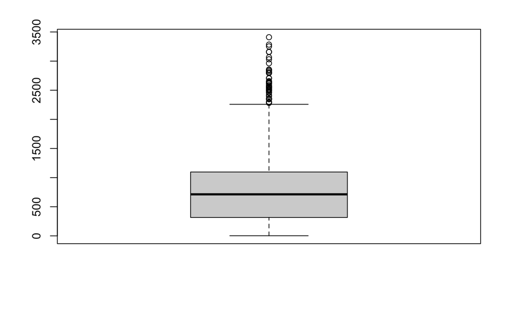

```r
boxplot(bikesharing_day$casual)
```

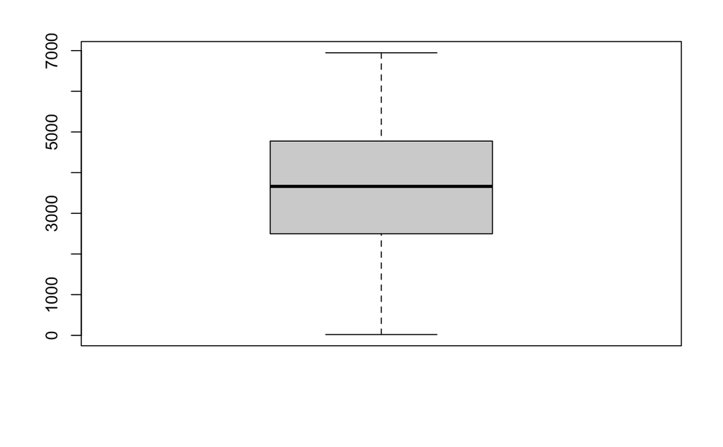

```r
boxplot(bikesharing_day$registered)
```

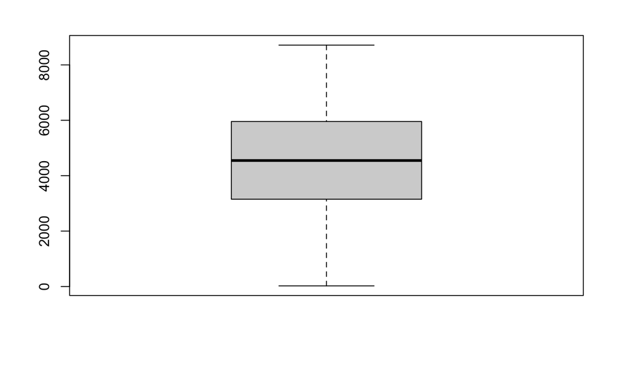

```r
boxplot(bikesharing_day$cnt)
```

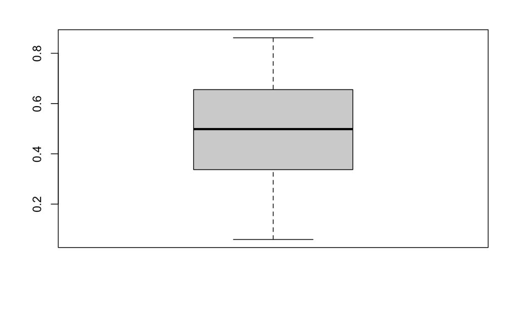

```r
boxplot(bikesharing_day$temp)
```

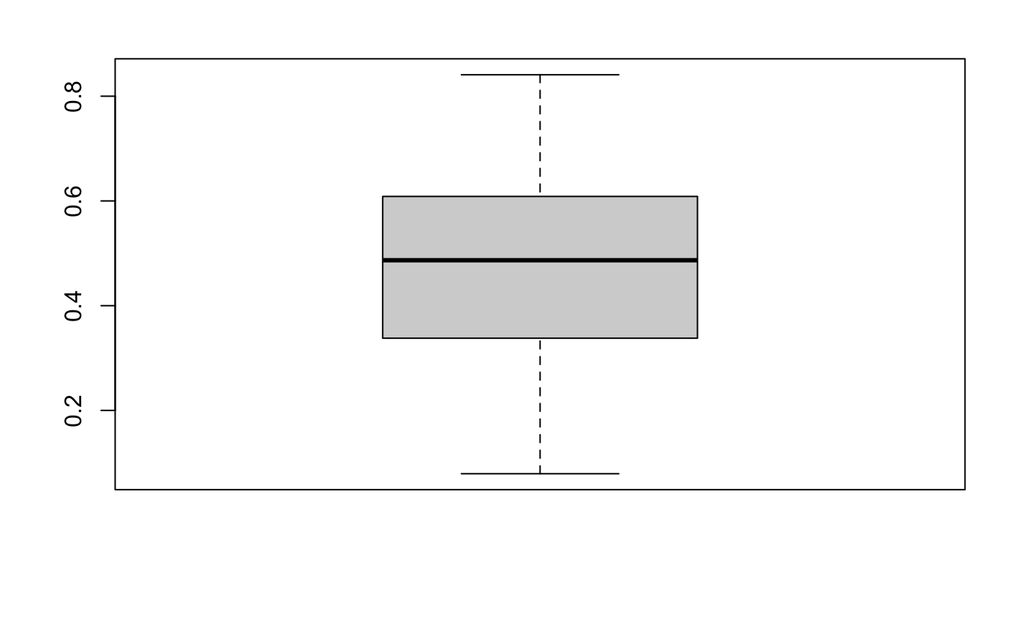

```r
boxplot(bikesharing_day$atemp)
```

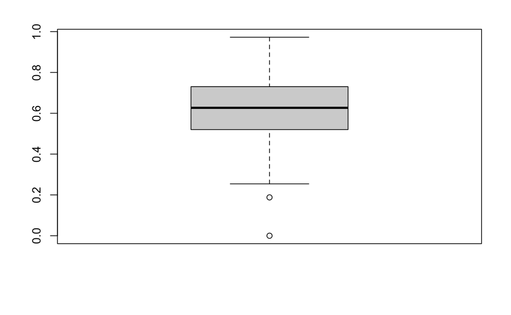

```r
boxplot(bikesharing_day$hum)
```

#It seems that there are outliers in the variable casual and hum

```r
boxplot(bikesharing_day$casual,plot=FALSE)$out
```

```
 [1] 2355 2282 3065 2418 2521 2397 3155 2469 2301 2347 3252 2795 2846 2541 2496 2622 3410 2704 2855 3283 2557 2795 2494 2708 2963 2634 2657 2551
[29] 2562 2355 2544 2345 2827 2352 2613 2570 3160 2512 2454 2589 3031 2806 2643 2290
```

```r
boxplot(bikesharing_day$hum,plot=FALSE)$out
```

```
[1] 0.187917 0.000000
```

#Remove outliers of hum and casual variables

```r
outliers<-boxplot(bikesharing_day$casual,plot=FALSE)$out
bikesharing_day[which(bikesharing_day$casual%in% outliers),]
```

|  | instant | dteday | season | yr | mnth | holiday | weekday | workingday | weathersit | temp | atemp | hum | windspeed | casual | registered | cnt |
| --- | --- | --- | --- | --- | --- | --- | --- | --- | --- | --- | --- | --- | --- | --- | --- | --- |
| 149 | 149 | 2011-05-29 | 2 | 0 | 5 | 0 | 0 | 0 | 1 | 0.667500 | 0.615550 | 0.818750 | 0.2139380 | 2355 | 2433 | 4788 |
| 184 | 184 | 2011-07-03 | 3 | 0 | 7 | 0 | 0 | 0 | 2 | 0.716667 | 0.668575 | 0.682500 | 0.2288580 | 2282 | 2367 | 4649 |
| 185 | 185 | 2011-07-04 | 3 | 0 | 7 | 1 | 1 | 0 | 2 | 0.726667 | 0.665417 | 0.637917 | 0.0814792 | 3065 | 2978 | 6043 |
| 197 | 197 | 2011-07-16 | 3 | 0 | 7 | 0 | 6 | 0 | 1 | 0.686667 | 0.638263 | 0.585000 | 0.2083420 | 2418 | 3505 | 5923 |
| 247 | 247 | 2011-09-04 | 3 | 0 | 9 | 0 | 0 | 0 | 1 | 0.709167 | 0.665429 | 0.742083 | 0.2064670 | 2521 | 2419 | 4940 |
| 282 | 282 | 2011-10-09 | 4 | 0 | 10 | 0 | 0 | 0 | 1 | 0.540833 | 0.523983 | 0.727500 | 0.0634500 | 2397 | 3114 | 5511 |
| 442 | 442 | 2012-03-17 | 1 | 1 | 3 | 0 | 6 | 0 | 2 | 0.514167 | 0.505046 | 0.755833 | 0.1107040 | 3155 | 4681 | 7836 |
| 448 | 448 | 2012-03-23 | 2 | 1 | 3 | 0 | 5 | 1 | 2 | 0.601667 | 0.570067 | 0.694167 | 0.1163000 | 2469 | 5893 | 8362 |
| 456 | 456 | 2012-03-31 | 2 | 1 | 3 | 0 | 6 | 0 | 2 | 0.424167 | 0.421708 | 0.738333 | 0.2506170 | 2301 | 3934 | 6235 |
| 457 | 457 | 2012-04-01 | 2 | 1 | 4 | 0 | 0 | 0 | 2 | 0.425833 | 0.417287 | 0.676250 | 0.1722670 | 2347 | 3694 | 6041 |

[output cut: 34 more lines]

```r
bikesharing_day<-bikesharing_day[-which(bikesharing_day$casual %in% outliers),]

outliers1<-boxplot(bikesharing_day$hum,plot=FALSE)$out
bikesharing_day[which(bikesharing_day$hum%in% outliers1),]
```

|  | instant | dteday | season | yr | mnth | holiday | weekday | workingday | weathersit | temp | atemp | hum | windspeed | casual | registered | cnt |
| --- | --- | --- | --- | --- | --- | --- | --- | --- | --- | --- | --- | --- | --- | --- | --- | --- |
| 50 | 50 | 2011-02-19 | 1 | 0 | 2 | 0 | 6 | 0 | 1 | 0.399167 | 0.391404 | 0.187917 | 0.507463 | 532 | 1103 | 1635 |
| 69 | 69 | 2011-03-10 | 1 | 0 | 3 | 0 | 4 | 1 | 3 | 0.389091 | 0.385668 | 0.000000 | 0.261877 | 46 | 577 | 623 |

```r
bikesharing_day1<-bikesharing_day[-which(bikesharing_day$hum %in% outliers1),]
```

#Feature Engineering

```r
bikesharing_day1$original_temp<-(bikesharing_day1$temp*41)
bikesharing_day1$original_atemp<-(bikesharing_day1$atemp*50)
bikesharing_day1$original_windspeed<-(bikesharing_day1$windspeed*67)
bikesharing_day1$original_hum<-(bikesharing_day1$hum*100)
```

- weathersit :
  - 1: Clear, Few clouds, Partly cloudy, Partly cloudy
  - 2: Mist + Cloudy, Mist + Broken clouds, Mist + Few clouds, Mist
  - 3: Light Snow, Light Rain + Thunderstorm + Scattered clouds, Light Rain + Scattered clouds
  - 4: Heavy Rain + Ice Pallets + Thunderstorm + Mist, Snow + Fog

```r
bikesharing_day1$weekday <- factor(bikesharing_day1$weekday, levels = c(0,1,2,3,4,5,6), labels =  c("Sun", "Mon", "Tue", "Wed", "Thr", "Fri", "Sat"))
bikesharing_day1$season <- factor(bikesharing_day1$season, levels = c(1,2,3,4), labels =  c("Spring","Summer","Fall","winter"))
bikesharing_day1$weathersit <- factor(bikesharing_day1$weathersit, levels = c(1,2,3,4), labels =  c("Clear","Mist","Light","Extreme"))
```

```r
bikesharing_day1
```

|  | instant | dteday | season | yr | mnth | holiday | weekday | workingday | weathersit | temp | atemp | hum | windspeed | casual | registered | cnt | original_temp | original_atemp | original_windspeed | original_hum |
| --- | --- | --- | --- | --- | --- | --- | --- | --- | --- | --- | --- | --- | --- | --- | --- | --- | --- | --- | --- | --- |
| 1 | 1 | 2011-01-01 | Spring | 0 | 1 | 0 | Sat | 0 | Mist | 0.3441670 | 0.3636250 | 0.805833 | 0.1604460 | 331 | 654 | 985 | 14.110847 | 18.181250 | 10.749882 | 80.5833 |
| 2 | 2 | 2011-01-02 | Spring | 0 | 1 | 0 | Sun | 0 | Mist | 0.3634780 | 0.3537390 | 0.696087 | 0.2485390 | 131 | 670 | 801 | 14.902598 | 17.686950 | 16.652113 | 69.6087 |
| 3 | 3 | 2011-01-03 | Spring | 0 | 1 | 0 | Mon | 1 | Clear | 0.1963640 | 0.1894050 | 0.437273 | 0.2483090 | 120 | 1229 | 1349 | 8.050924 | 9.470250 | 16.636703 | 43.7273 |
| 4 | 4 | 2011-01-04 | Spring | 0 | 1 | 0 | Tue | 1 | Clear | 0.2000000 | 0.2121220 | 0.590435 | 0.1602960 | 108 | 1454 | 1562 | 8.200000 | 10.606100 | 10.739832 | 59.0435 |
| 5 | 5 | 2011-01-05 | Spring | 0 | 1 | 0 | Wed | 1 | Clear | 0.2269570 | 0.2292700 | 0.436957 | 0.1869000 | 82 | 1518 | 1600 | 9.305237 | 11.463500 | 12.522300 | 43.6957 |
| 6 | 6 | 2011-01-06 | Spring | 0 | 1 | 0 | Thr | 1 | Clear | 0.2043480 | 0.2332090 | 0.518261 | 0.0895652 | 88 | 1518 | 1606 | 8.378268 | 11.660450 | 6.000868 | 51.8261 |
| 7 | 7 | 2011-01-07 | Spring | 0 | 1 | 0 | Fri | 1 | Mist | 0.1965220 | 0.2088390 | 0.498696 | 0.1687260 | 148 | 1362 | 1510 | 8.057402 | 10.441950 | 11.304642 | 49.8696 |
| 8 | 8 | 2011-01-08 | Spring | 0 | 1 | 0 | Sat | 0 | Mist | 0.1650000 | 0.1622540 | 0.535833 | 0.2668040 | 68 | 891 | 959 | 6.765000 | 8.112700 | 17.875868 | 53.5833 |
| 9 | 9 | 2011-01-09 | Spring | 0 | 1 | 0 | Sun | 0 | Clear | 0.1383330 | 0.1161750 | 0.434167 | 0.3619500 | 54 | 768 | 822 | 5.671653 | 5.808750 | 24.250650 | 43.4167 |
| 10 | 10 | 2011-01-10 | Spring | 0 | 1 | 0 | Mon | 1 | Clear | 0.1508330 | 0.1508880 | 0.482917 | 0.2232670 | 41 | 1280 | 1321 | 6.184153 | 7.544400 | 14.958889 | 48.2917 |

[output cut: 675 more lines]

#Explortary Data Analysis

#Seasonal Pattern of temperature change

```r
library(dplyr)
season_summary <- bikesharing_day1 %>%
  group_by(season) %>%
  summarise(temp.min = min(original_temp),temp.max = max(original_temp),temp.med = median(original_temp),temp.stdev = sd(original_temp),temp.mean = mean(original_temp),  count = n())
season_summary
```

| season | temp.min | temp.max | temp.med | temp.stdev | temp.mean | count |
| --- | --- | --- | --- | --- | --- | --- |
| Spring | 2.424346 | 23.47250 | 11.64043 | 4.172783 | 12.11340 | 178 |
| Summer | 10.374763 | 33.14165 | 22.37917 | 5.130834 | 22.07993 | 164 |
| Fall | 19.235847 | 35.32835 | 29.34915 | 2.965515 | 28.96745 | 172 |
| winter | 9.054153 | 26.95750 | 16.43415 | 4.429039 | 17.18538 | 171 |

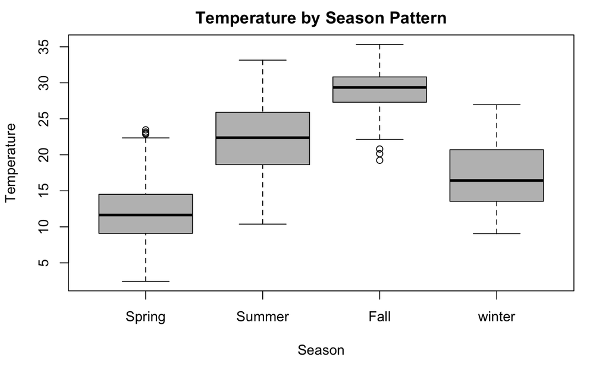

```r
boxplot(original_temp ~ season,data = bikesharing_day1,xlab = "Season",ylab = "Temperature",main = "Temperature by Season Pattern",col = "grey")
```

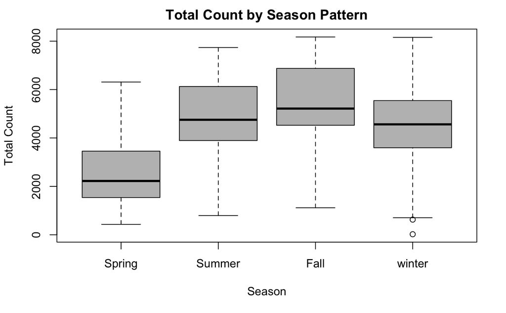

```r
boxplot(cnt ~ season,data = bikesharing_day1,xlab = "Season",ylab = "Total Count",main = "Total Count by Season Pattern",col = "grey")
```

#From the summary analysis, the lowest extreme and average temperature are in the spring (2.42°C,12.11°C) while the highest extreme and average temperature are in the fall (35.32°C,28.97°C).The boxplot shows that the lowest temperatures are at spring season and followed by winter, while the highest temperatures at fall and followed by summer. Those outliers in the boxplot might be season shifts and extreme weather circumstances.

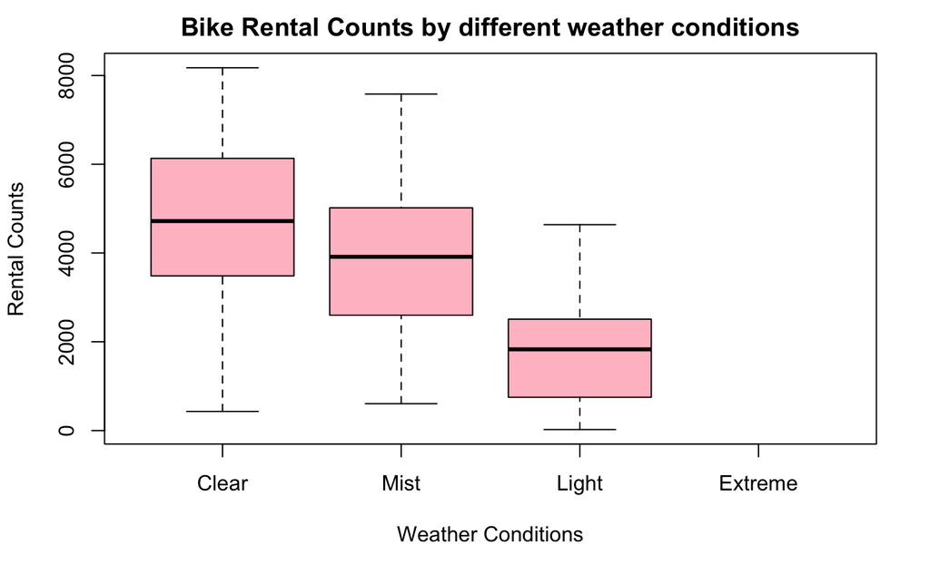

```r
boxplot(cnt ~ weathersit,data = bikesharing_day1,xlab = "Weather Conditions",ylab = "Rental Counts",main = "Bike Rental Counts by different weather conditions",col = "pink")
```

- weathersit :
  - 1: Clear, Few clouds, Partly cloudy, Partly cloudy
  - 2: Mist + Cloudy, Mist + Broken clouds, Mist + Few clouds, Mist
  - 3: Light Snow, Light Rain + Thunderstorm + Scattered clouds, Light Rain + Scattered clouds
  - 4: Heavy Rain + Ice Pallets + Thunderstorm + Mist, Snow + Fog

#There are no type 4 conditions in our dataset. #The boxplot demonstrates that the highest mean value of rentals have days with the 1st weather type (clear, partly cloudy etc.),while the lowest number of rents happened at the type 3 (light snow, light rain+thunderstorm+scattered clouds,light rain).

#Analaysis of Variance

```r
summary(aov(cnt~season,data=bikesharing_day1))
```

```
             Df    Sum Sq   Mean Sq F value Pr(>F)
season        3 8.283e+08 276089446   122.1 <2e-16 ***
Residuals   681 1.540e+09   2261106
---
Signif. codes:  0 ‘***’ 0.001 ‘**’ 0.01 ‘*’ 0.05 ‘.’ 0.1 ‘ ’ 1
```

```r
summary(aov(cnt~weathersit,data=bikesharing_day1))
```

```
             Df    Sum Sq   Mean Sq F value   Pr(>F)
weathersit    2 2.275e+08 113730220   36.23 1.11e-15 ***
Residuals   682 2.141e+09   3138741
---
Signif. codes:  0 ‘***’ 0.001 ‘**’ 0.01 ‘*’ 0.05 ‘.’ 0.1 ‘ ’ 1
```

```r
summary(aov(cnt~holiday,data=bikesharing_day1))
```

```
             Df    Sum Sq  Mean Sq F value Pr(>F)
holiday       1 2.138e+07 21377182   6.222 0.0129 *
Residuals   683 2.347e+09  3435878
---
Signif. codes:  0 ‘***’ 0.001 ‘**’ 0.01 ‘*’ 0.05 ‘.’ 0.1 ‘ ’ 1
```

#The ANOVA test shows that the correlation among bike sharing counts and season,weather conditions and holiday are all signficant, because p-values are all very small. The signficant level is: season>weathersit>holiday.

```r
TukeyHSD(aov(cnt~season,data=bikesharing_day1))
```

```
  Tukey multiple comparisons of means
    95% family-wise confidence level

Fit: aov(formula = cnt ~ season, data = bikesharing_day1)

$season
                   diff        lwr       upr     p adj
Summer-Spring 2154.0878  1734.9239 2573.2517 0.0000000
Fall-Spring   2940.4761  2526.4168 3354.5354 0.0000000
winter-Spring 2022.0246  1607.3500 2436.6991 0.0000000
Fall-Summer    786.3883   363.7330 1209.0435 0.0000121
winter-Summer -132.0633  -555.3213  291.1947 0.8527629
winter-Fall   -918.4515 -1336.6549 -500.2481 0.0000001
```

```r
TukeyHSD(aov(cnt~weathersit,data=bikesharing_day1))
```

```
  Tukey multiple comparisons of means
    95% family-wise confidence level

Fit: aov(formula = cnt ~ weathersit, data = bikesharing_day1)

$weathersit
                  diff       lwr        upr   p adj
Mist-Clear   -811.0251 -1148.603  -473.4477 1.0e-07
Light-Clear -2849.2698 -3801.162 -1897.3776 0.0e+00
Light-Mist  -2038.2447 -3007.531 -1068.9588 2.9e-06
```

#According to the result of Tukey’s Honest Significant Difference test, the most significant difference in total number of bike sharing counts are between Fall and Spring. While the least significant difference is between Winter and Summer. Additionally for weather conditions, the most signficant difference would be between light weather to clear, while the least significant difference is between mist and clear.

#Patterns of variables change

```r
library(dplyr)
mean.bymonth <- data.frame("mnth" = c(1:12),
                          "mnth.name" = c("01-Jan", "02-Feb", "03-Mar", "04-Apr", "05-May", "06-June", "07-July", "08-Aug", "09-Sept", "10-Oct", "11-Nov", "12-Dec"), stringsAsFactors = FALSE)

bikeday
```

| mnth | instant | dteday | season | yr | holiday | weekday | workingday | weathersit | temp | atemp | hum | windspeed | casual | registered | cnt | original_temp | original_atemp | original_windspeed | original_hum | mnth.name |
| --- | --- | --- | --- | --- | --- | --- | --- | --- | --- | --- | --- | --- | --- | --- | --- | --- | --- | --- | --- | --- |
| 1 | 1 | 2011-01-01 | Spring | 0 | 0 | Sat | 0 | Mist | 0.3441670 | 0.3636250 | 0.805833 | 0.1604460 | 331 | 654 | 985 | 14.110847 | 18.181250 | 10.749882 | 80.5833 | 01-Jan |
| 1 | 2 | 2011-01-02 | Spring | 0 | 0 | Sun | 0 | Mist | 0.3634780 | 0.3537390 | 0.696087 | 0.2485390 | 131 | 670 | 801 | 14.902598 | 17.686950 | 16.652113 | 69.6087 | 01-Jan |
| 1 | 3 | 2011-01-03 | Spring | 0 | 0 | Mon | 1 | Clear | 0.1963640 | 0.1894050 | 0.437273 | 0.2483090 | 120 | 1229 | 1349 | 8.050924 | 9.470250 | 16.636703 | 43.7273 | 01-Jan |
| 1 | 4 | 2011-01-04 | Spring | 0 | 0 | Tue | 1 | Clear | 0.2000000 | 0.2121220 | 0.590435 | 0.1602960 | 108 | 1454 | 1562 | 8.200000 | 10.606100 | 10.739832 | 59.0435 | 01-Jan |
| 1 | 5 | 2011-01-05 | Spring | 0 | 0 | Wed | 1 | Clear | 0.2269570 | 0.2292700 | 0.436957 | 0.1869000 | 82 | 1518 | 1600 | 9.305237 | 11.463500 | 12.522300 | 43.6957 | 01-Jan |
| 1 | 6 | 2011-01-06 | Spring | 0 | 0 | Thr | 1 | Clear | 0.2043480 | 0.2332090 | 0.518261 | 0.0895652 | 88 | 1518 | 1606 | 8.378268 | 11.660450 | 6.000868 | 51.8261 | 01-Jan |
| 1 | 7 | 2011-01-07 | Spring | 0 | 0 | Fri | 1 | Mist | 0.1965220 | 0.2088390 | 0.498696 | 0.1687260 | 148 | 1362 | 1510 | 8.057402 | 10.441950 | 11.304642 | 49.8696 | 01-Jan |
| 1 | 8 | 2011-01-08 | Spring | 0 | 0 | Sat | 0 | Mist | 0.1650000 | 0.1622540 | 0.535833 | 0.2668040 | 68 | 891 | 959 | 6.765000 | 8.112700 | 17.875868 | 53.5833 | 01-Jan |
| 1 | 9 | 2011-01-09 | Spring | 0 | 0 | Sun | 0 | Clear | 0.1383330 | 0.1161750 | 0.434167 | 0.3619500 | 54 | 768 | 822 | 5.671653 | 5.808750 | 24.250650 | 43.4167 | 01-Jan |
| 1 | 10 | 2011-01-10 | Spring | 0 | 0 | Mon | 1 | Clear | 0.1508330 | 0.1508880 | 0.482917 | 0.2232670 | 41 | 1280 | 1321 | 6.184153 | 7.544400 | 14.958889 | 48.2917 | 01-Jan |

[output cut: 675 more lines]

```r
bikeday <- merge(x=bikesharing_day1, y= mean.bymonth, by = 'mnth')

month_groups <- bikeday %>% group_by(mnth.name) %>% summarise(mean.temp = mean(original_temp), mean.hum = mean(original_hum), mean.windspeed=mean(original_windspeed),mean.rentals = mean(cnt))
month_groups
```

| mnth.name | mean.temp | mean.hum | mean.windspeed | mean.rentals |
| --- | --- | --- | --- | --- |
| 01-Jan | 9.694201 | 58.58283 | 13.82229 | 2176.339 |
| 02-Feb | 12.195113 | 57.42423 | 14.10173 | 2673.518 |
| 03-Mar | 15.752703 | 59.13296 | 15.09564 | 3549.379 |
| 04-Apr | 19.132039 | 59.38113 | 15.74154 | 4272.364 |
| 05-May | 24.074847 | 69.56867 | 12.29106 | 5148.019 |
| 06-June | 28.197169 | 58.40015 | 12.60794 | 5548.189 |
| 07-July | 31.152067 | 59.21875 | 11.25171 | 5474.125 |
| 08-Aug | 29.014601 | 63.87100 | 11.48559 | 5608.417 |
| 09-Sept | 25.143984 | 73.04156 | 10.77994 | 5525.058 |
| 10-Oct | 19.765951 | 69.53205 | 11.75739 | 5050.586 |

[output cut: 2 more lines]

```r
NA
```

```r
par(mfrow=c(2,2))
barplot(height = month_groups$mean.rentals,
        names.arg = month_groups$mnth.name ,col = "orange", main = "Mean rentals" )

barplot(height = month_groups$mean.windspeed,
        names.arg = month_groups$mnth.name,col = "yellow", main = "Mean Windspeed (km/h)" )
```

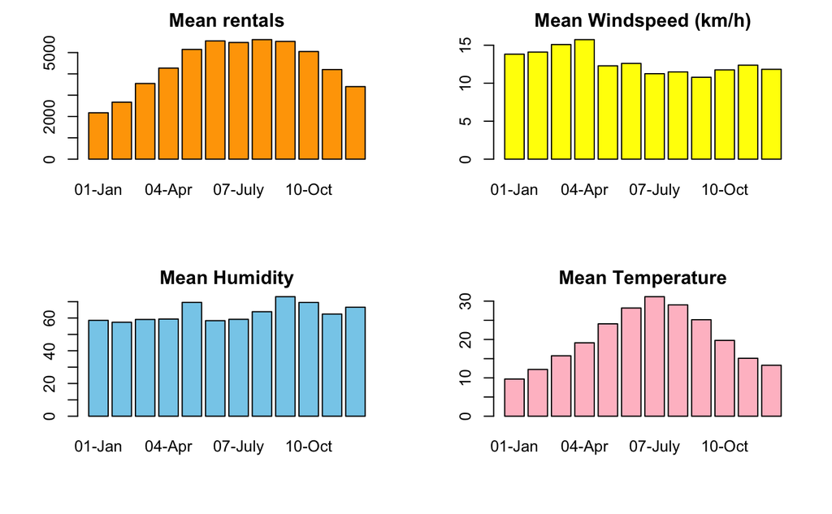

```r
barplot(height = month_groups$mean.hum,
        names.arg = month_groups$mnth.name,col = "skyblue", main = "Mean Humidity" )


barplot(height = month_groups$mean.temp,
        names.arg = month_groups$mnth.name,col = "pink", main = "Mean Temperature" )
```

#Data Modeling

```r
plot(x = 1, y = 1, xlab = "Temperature", ylab = "Bike Sharing Count", type = "n", main = "Correlation between temperature and bike sharing counts",
xlim = c(0, 40), ylim = c(0, 7000))
points(bikesharing_day1$original_temp,bikesharing_day1$casual,pch=16,col='red')
```

```r
points(bikesharing_day1$original_temp,bikesharing_day1$registered,pch=16,col='grey')

legend("topleft",legend = c("casual","registered"),col = c("red","grey"),pch=c(16,16),bg="white")
```

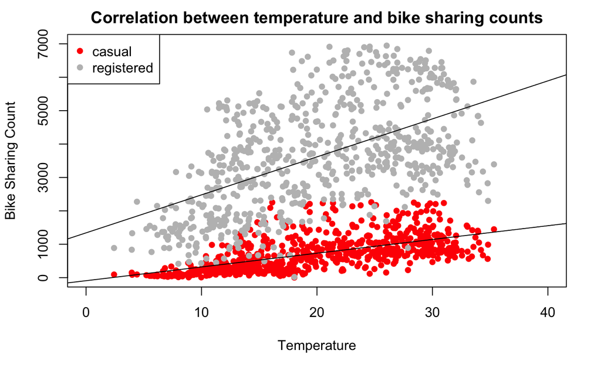

```r
abline(lm(bikesharing_day1$registered~bikesharing_day1$original_temp))
abline(lm(bikesharing_day1$casual~bikesharing_day1$original_temp))
```

```r
summary(lm(bikesharing_day1$registered~bikesharing_day1$original_temp))
```

```
Call:
lm(formula = bikesharing_day1$registered ~ bikesharing_day1$original_temp)

Residuals:
    Min      1Q  Median      3Q     Max
-3624.9  -992.9  -148.4  1000.4  3365.3

Coefficients:
                               Estimate Std. Error t value Pr(>|t|)
(Intercept)                     1341.11     142.60   9.405   <2e-16 ***
bikesharing_day1$original_temp   113.80       6.67  17.062   <2e-16 ***
---
Signif. codes:  0 ‘***’ 0.001 ‘**’ 0.01 ‘*’ 0.05 ‘.’ 0.1 ‘ ’ 1

Residual standard error: 1320 on 683 degrees of freedom
Multiple R-squared:  0.2988,    Adjusted R-squared:  0.2978
F-statistic: 291.1 on 1 and 683 DF,  p-value: < 2.2e-16
```

```r
summary(lm(bikesharing_day1$casual~bikesharing_day1$original_temp))
```

```
Call:
lm(formula = bikesharing_day1$casual ~ bikesharing_day1$original_temp)

Residuals:
   Min     1Q Median     3Q    Max
-832.2 -266.1 -104.3  152.2 1678.3

Coefficients:
                               Estimate Std. Error t value Pr(>|t|)
(Intercept)                     -91.082     45.167  -2.017   0.0441 *
bikesharing_day1$original_temp   41.224      2.113  19.514   <2e-16 ***
---
Signif. codes:  0 ‘***’ 0.001 ‘**’ 0.01 ‘*’ 0.05 ‘.’ 0.1 ‘ ’ 1

Residual standard error: 418.2 on 683 degrees of freedom
Multiple R-squared:  0.3579,    Adjusted R-squared:  0.357
F-statistic: 380.8 on 1 and 683 DF,  p-value: < 2.2e-16
```

```r
plot(x = 1, y = 1, xlab = "Temperature", ylab = "Bike Sharing Count", type = "n", main = "Correlation between temperature and bike sharing counts 2011/2012",
xlim = c(0, 40), ylim = c(0, 7000))
points(bikesharing_day1$original_temp[bikesharing_day1$yr==0],bikesharing_day1$cnt[bikesharing_day1$yr==0],pch=16,col='blue')
```

```r
points(bikesharing_day1$original_temp[bikesharing_day1$yr==1],bikesharing_day1$cnt[bikesharing_day1$yr==1],pch=16,col='brown')

legend("topleft",legend = c("2011","2012"),col = c("blue","brown"),pch=c(16,16),bg="white")
```

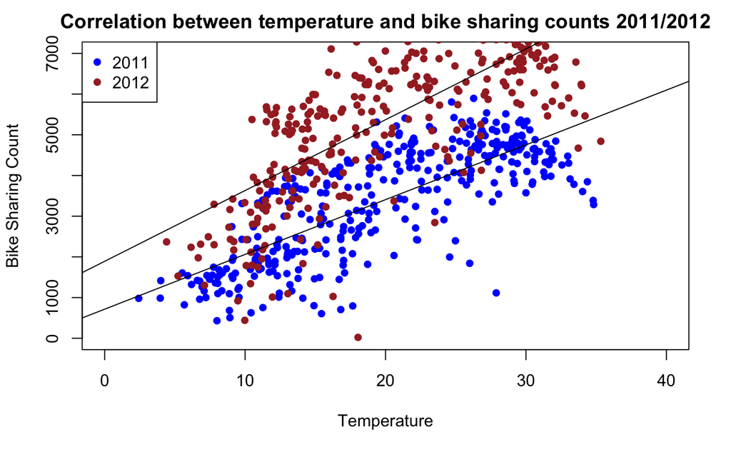

```r
abline(lm(bikesharing_day1$cnt[bikesharing_day1$yr==0]~bikesharing_day1$original_temp[bikesharing_day1$yr==0]))
abline(lm(bikesharing_day1$cnt[bikesharing_day1$yr==1]~bikesharing_day1$original_temp[bikesharing_day1$yr==1]))
```

```r
summary(lm(bikesharing_day1$cnt[bikesharing_day1$yr==0]~bikesharing_day1$original_temp[bikesharing_day1$yr==0]))
```

```
Call:
lm(formula = bikesharing_day1$cnt[bikesharing_day1$yr == 0] ~
    bikesharing_day1$original_temp[bikesharing_day1$yr == 0])

Residuals:
    Min      1Q  Median      3Q     Max
-3353.2  -509.0   -60.4   662.1  1989.1

Coefficients:
                                                         Estimate Std. Error t value Pr(>|t|)
(Intercept)                                               714.984    125.762   5.685 2.73e-08 ***
bikesharing_day1$original_temp[bikesharing_day1$yr == 0]  134.620      5.901  22.814  < 2e-16 ***
---
Signif. codes:  0 ‘***’ 0.001 ‘**’ 0.01 ‘*’ 0.05 ‘.’ 0.1 ‘ ’ 1

Residual standard error: 866.6 on 355 degrees of freedom
Multiple R-squared:  0.5945,    Adjusted R-squared:  0.5934
F-statistic: 520.5 on 1 and 355 DF,  p-value: < 2.2e-16
```

```r
summary(lm(bikesharing_day1$cnt[bikesharing_day1$yr==1]~bikesharing_day1$original_temp[bikesharing_day1$yr==1]))
```

```
Call:
lm(formula = bikesharing_day1$cnt[bikesharing_day1$yr == 1] ~
    bikesharing_day1$original_temp[bikesharing_day1$yr == 1])

Residuals:
    Min      1Q  Median      3Q     Max
-5007.5  -729.5     2.0   922.3  2576.1

Coefficients:
                                                         Estimate Std. Error t value Pr(>|t|)
(Intercept)                                              1891.404    197.458   9.579   <2e-16 ***
bikesharing_day1$original_temp[bikesharing_day1$yr == 1]  173.953      9.204  18.899   <2e-16 ***
---
Signif. codes:  0 ‘***’ 0.001 ‘**’ 0.01 ‘*’ 0.05 ‘.’ 0.1 ‘ ’ 1

Residual standard error: 1221 on 326 degrees of freedom
Multiple R-squared:  0.5228,    Adjusted R-squared:  0.5214
F-statistic: 357.2 on 1 and 326 DF,  p-value: < 2.2e-16
```

```r
plot(x = 1, y = 1, xlab = "Temperature", ylab = "Bike Sharing Count", type = "n", main = "Temperature and rental counts(weather conditions)",
xlim = c(0, 40), ylim = c(0, 7000))
points(bikesharing_day1$original_temp[bikesharing_day1$weathersit=='Clear'],bikesharing_day1$cnt[bikesharing_day1$weathersit=='Clear'],pch=16,col='skyblue')
```

```r
points(bikesharing_day1$original_temp[bikesharing_day1$weathersit=='Mist'],bikesharing_day1$cnt[bikesharing_day1$weathersit=='Mist'],pch=16,col='green')
points(bikesharing_day1$original_temp[bikesharing_day1$weathersit=='Light'],bikesharing_day1$cnt[bikesharing_day1$weathersit=='Light'],pch=16,col='pink')
```

```r
legend("topleft",legend = c("Clear","Mist",'Light'),col = c("skyblue","green","pink"),pch=c(16,16),bg="white")

abline(lm(bikesharing_day1$cnt[bikesharing_day1$weathersit=='Clear']~bikesharing_day1$original_temp[bikesharing_day1$weathersit=='Clear']))
```

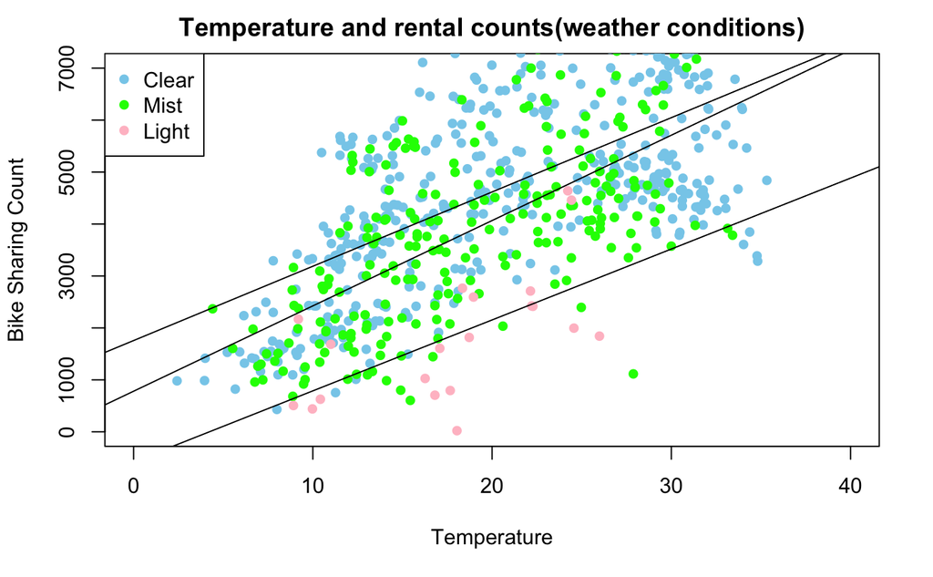

```r
abline(lm(bikesharing_day1$cnt[bikesharing_day1$weathersit=='Mist']~bikesharing_day1$original_temp[bikesharing_day1$weathersit=='Mist']))
abline(lm(bikesharing_day1$cnt[bikesharing_day1$weathersit=='Light']~bikesharing_day1$original_temp[bikesharing_day1$weathersit=='Light']))
```

```r
summary(lm(bikesharing_day1$cnt[bikesharing_day1$weathersit=='Clear']~bikesharing_day1$original_temp[bikesharing_day1$weathersit=='Clear']))
```

```
Call:
lm(formula = bikesharing_day1$cnt[bikesharing_day1$weathersit ==
    "Clear"] ~ bikesharing_day1$original_temp[bikesharing_day1$weathersit ==
    "Clear"])

Residuals:
   Min     1Q Median     3Q    Max
 -3453  -1196    -97   1083   3262

Coefficients:
                                                                       Estimate Std. Error t value Pr(>|t|)
(Intercept)                                                            1756.786    189.035   9.293   <2e-16 ***
bikesharing_day1$original_temp[bikesharing_day1$weathersit == "Clear"]  143.074      8.541  16.751   <2e-16 ***
---
Signif. codes:  0 ‘***’ 0.001 ‘**’ 0.01 ‘*’ 0.05 ‘.’ 0.1 ‘ ’ 1

Residual standard error: 1409 on 428 degrees of freedom
Multiple R-squared:  0.396, Adjusted R-squared:  0.3946
F-statistic: 280.6 on 1 and 428 DF,  p-value: < 2.2e-16
```

```r
summary(lm(bikesharing_day1$cnt[bikesharing_day1$weathersit=='Mist']~bikesharing_day1$original_temp[bikesharing_day1$weathersit=='Mist']))
```

```
Call:
lm(formula = bikesharing_day1$cnt[bikesharing_day1$weathersit ==
    "Mist"] ~ bikesharing_day1$original_temp[bikesharing_day1$weathersit ==
    "Mist"])

Residuals:
    Min      1Q  Median      3Q     Max
-4247.6  -960.7  -129.2   857.2  3207.4

Coefficients:
                                                                      Estimate Std. Error t value Pr(>|t|)
(Intercept)                                                             781.54     256.90   3.042  0.00262 **
bikesharing_day1$original_temp[bikesharing_day1$weathersit == "Mist"]   164.31      12.74  12.896  < 2e-16 ***
---
Signif. codes:  0 ‘***’ 0.001 ‘**’ 0.01 ‘*’ 0.05 ‘.’ 0.1 ‘ ’ 1

Residual standard error: 1328 on 233 degrees of freedom
Multiple R-squared:  0.4165,    Adjusted R-squared:  0.414
F-statistic: 166.3 on 1 and 233 DF,  p-value: < 2.2e-16
```

```r
summary(lm(bikesharing_day1$cnt[bikesharing_day1$weathersit=='Light']~bikesharing_day1$original_temp[bikesharing_day1$weathersit=='Light']))
```

```
Call:
lm(formula = bikesharing_day1$cnt[bikesharing_day1$weathersit ==
    "Light"] ~ bikesharing_day1$original_temp[bikesharing_day1$weathersit ==
    "Light"])

Residuals:
    Min      1Q  Median      3Q     Max
-1864.6  -658.2  -141.9   626.0  1907.8

Coefficients:
                                                                       Estimate Std. Error t value Pr(>|t|)
(Intercept)                                                             -577.12     787.41  -0.733  0.47304
bikesharing_day1$original_temp[bikesharing_day1$weathersit == "Light"]   136.57      42.21   3.235  0.00459 **
---
Signif. codes:  0 ‘***’ 0.001 ‘**’ 0.01 ‘*’ 0.05 ‘.’ 0.1 ‘ ’ 1

Residual standard error: 1015 on 18 degrees of freedom
Multiple R-squared:  0.3677,    Adjusted R-squared:  0.3326
F-statistic: 10.47 on 1 and 18 DF,  p-value: 0.004593
```

- instant: record index
- dteday : date
- season : season (1:spring, 2:summer, 3:fall, 4:winter)
- yr : year (0: 2011, 1:2012)
- mnth : month ( 1 to 12)
- hr : hour (0 to 23)
- holiday : weather day is holiday or not (extracted from http://dchr.dc.gov/page/holiday-schedule)
- weekday : day of the week
- workingday : if day is neither weekend nor holiday is 1, otherwise is 0.
- weathersit :
  - 1: Clear, Few clouds, Partly cloudy, Partly cloudy
  - 2: Mist + Cloudy, Mist + Broken clouds, Mist + Few clouds, Mist
  - 3: Light Snow, Light Rain + Thunderstorm + Scattered clouds, Light Rain + Scattered clouds
  - 4: Heavy Rain + Ice Pallets + Thunderstorm + Mist, Snow + Fog
- temp : Normalized temperature in Celsius. The values are divided to 41 (max)
- atemp: Normalized feeling temperature in Celsius. The values are divided to 50 (max)
- hum: Normalized humidity. The values are divided to 100 (max)
- windspeed: Normalized wind speed. The values are divided to 67 (max)
- casual: count of casual users
- registered: count of registered users
- cnt: count of total rental bikes including both casual and registered

```r
model<-glm(log(cnt)~season+yr+weathersit+holiday+workingday+mnth+log(temp)+log(atemp)+log(hum)+log(windspeed),data=bikeday)
summary(model)
```

```
Call:
glm(formula = log(cnt) ~ season + yr + weathersit + holiday +
    workingday + mnth + log(temp) + log(atemp) + log(hum) + log(windspeed),
    data = bikeday)

Deviance Residuals:
    Min       1Q   Median       3Q      Max
-4.4980  -0.0884   0.0425   0.1447   0.9521

Coefficients:
                 Estimate Std. Error t value Pr(>|t|)
(Intercept)      7.982176   0.096967  82.318  < 2e-16 ***
seasonSummer     0.290686   0.042193   6.889 1.29e-11 ***
seasonFall       0.257499   0.056132   4.587 5.36e-06 ***
seasonwinter     0.475212   0.055874   8.505  < 2e-16 ***
yr               0.434169   0.022734  19.098  < 2e-16 ***
weathersitMist  -0.100580   0.029647  -3.393 0.000733 ***
weathersitLight -0.943272   0.075799 -12.444  < 2e-16 ***
holiday         -0.199521   0.072419  -2.755 0.006027 **
workingday       0.082912   0.026233   3.161 0.001645 **
mnth            -0.008052   0.005859  -1.374 0.169812
log(temp)        0.732180   0.205170   3.569 0.000384 ***
log(atemp)      -0.056706   0.215156  -0.264 0.792200
log(hum)        -0.295488   0.067367  -4.386 1.34e-05 ***
log(windspeed)  -0.151045   0.029330  -5.150 3.43e-07 ***
---
Signif. codes:  0 ‘***’ 0.001 ‘**’ 0.01 ‘*’ 0.05 ‘.’ 0.1 ‘ ’ 1

(Dispersion parameter for gaussian family taken to be 0.08457821)

    Null deviance: 228.306  on 684  degrees of freedom
Residual deviance:  56.752  on 671  degrees of freedom
AIC: 267.8

Number of Fisher Scoring iterations: 2
```

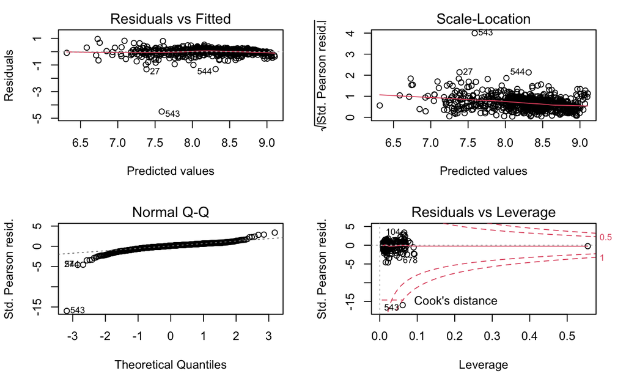

```r
layout(matrix(c(1,2,3,4),2,2))
plot(model)
```

```r
library(caret)
train_control <- trainControl(method="cv", number=200)
model_log <- train(log(cnt)~season+yr+weathersit+holiday+workingday+mnth+log(temp)+log(atemp)+log(hum)+log(windspeed), data=bikeday, trControl=train_control,method="glm")
model_log$resample
```

| RMSE | Rsquared | MAE | Resample |
| --- | --- | --- | --- |
| 0.17768076 | 0.95493014 | 0.13907793 | Fold001 |
| 0.22134714 | 1.00000000 | 0.18510117 | Fold002 |
| 0.45523858 | 0.94993809 | 0.31830941 | Fold003 |
| 0.78876090 | 0.60157065 | 0.54534209 | Fold004 |
| 0.51915233 | 0.98704318 | 0.44104277 | Fold005 |
| 0.11079324 | 1.00000000 | 0.10882243 | Fold006 |
| 0.12596221 | 0.92629035 | 0.07875729 | Fold007 |
| 0.14176858 | 0.99941465 | 0.12451931 | Fold008 |
| 0.13606193 | 0.92154697 | 0.12797818 | Fold009 |
| 0.14037929 | 0.83031198 | 0.11266787 | Fold010 |

[output cut: 190 more lines]

```r
NA
```

```r
model_log$results
```

|  | parameter | RMSE | Rsquared | MAE | RMSESD | RsquaredSD | MAESD |
| --- | --- | --- | --- | --- | --- | --- | --- |
| 1 | none | 0.2158052 | 0.8842497 | 0.1742116 | 0.2027036 | 0.1846237 | 0.1255136 |

#The accuracy score is 88% when applying the K-Fold Cross Validation.